# A/B Test Analysis on R

Abraham Cedeño

2023-01-14

## Section 1: Data preparation (Import, transform, sort and filter)

### Import libraries

```r
library(tidyverse)
library(stringr)
library(ggpubr)
library(knitr)
```

### Define paths to data sets

If you don’t keep your data in the same directory as the code, adapt the path names.

```r
dir1 <- "~"
dir2 <- "Desktop"
dir3 <- "AC"
dir4 <- "Useful"
dir5 <- "Carrer"
dir6 <- "Skills "
dir7 <- "3. Skills para trabajo"
dir8 <- "10. R data science, statistics, machine learning"
dir9 <- "Portfolio analysis"
dir10 <- "2. A:B test"
file_name  <- "Data"
PSDS_PATH <- file.path(dir1, dir2, dir3, dir4, dir5, dir6, dir7, dir8, dir9, dir10, file_name)
```

### Import csv files as data frames

```r
AB_Test_Results <- read_csv(file.path(PSDS_PATH, 'AB_Test_Results.csv'))
```

### Explore the data frame

```r
str(AB_Test_Results)
```

```
## spc_tbl_ [10,000 × 3] (S3: spec_tbl_df/tbl_df/tbl/data.frame)
##  $ USER_ID     : num [1:10000] 737 2423 9411 7311 6174 ...
##  $ VARIANT_NAME: chr [1:10000] "variant" "control" "control" "control" ...
##  $ REVENUE     : num [1:10000] 0 0 0 0 0 0 0 0 0 0 ...
##  - attr(*, "spec")=
##   .. cols(
##   ..   USER_ID = col_double(),
##   ..   VARIANT_NAME = col_character(),
##   ..   REVENUE = col_double()
##   .. )
##  - attr(*, "problems")=<externalptr>
```

### Sort ascending according to REVENUE, USER_ID and VARIANT

```r
AB_Test_Results<- arrange(AB_Test_Results,REVENUE, USER_ID, VARIANT_NAME)
```

## Section 2: Data process (clean)

### Duplicates

We start by plotting an histogram to observe if there were any duplicates.

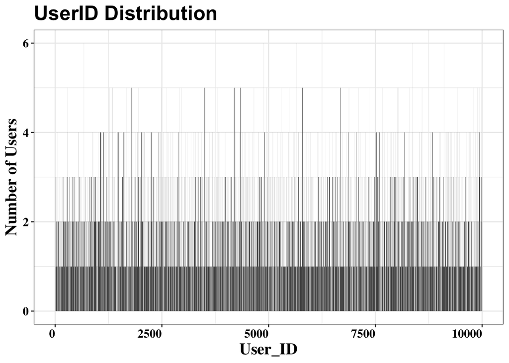

We use the function unique to eliminate rows that are completely equal.

```r
Unique_AB_Test_Results<- unique (AB_Test_Results[ , c('USER_ID','VARIANT_NAME','REVENUE') ] )
```

```r
nrow(Unique_AB_Test_Results)
```

```
## [1] 7933
```

We are left with 7933 observations(which means that more than 20% of the data were duplicates!).

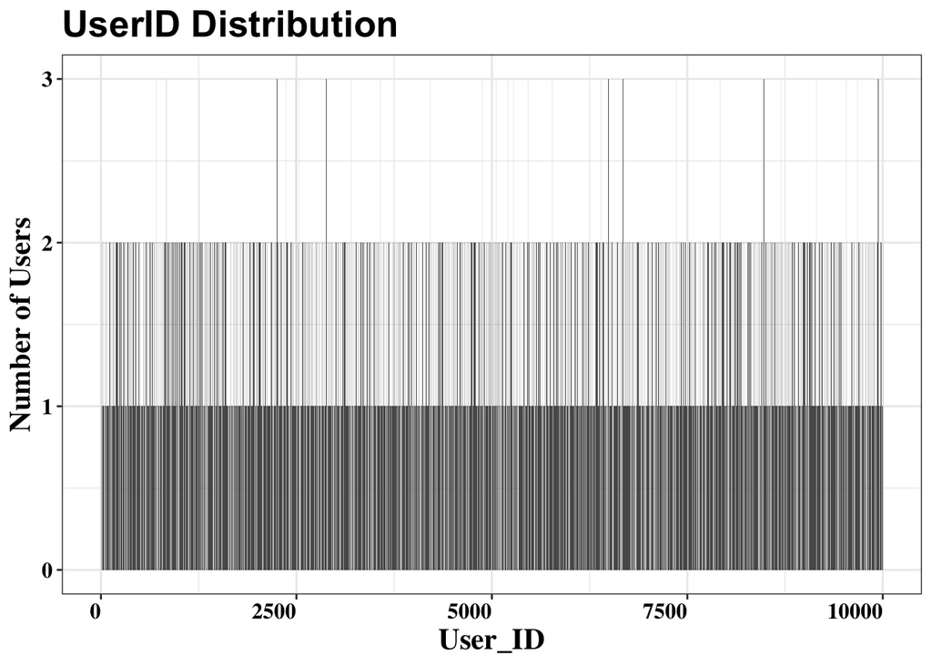

Exploring the data we found that there were users that took part in both of the tests (Example: user ID 3 was in both of the groups). This could mean that the user took the test 2 times with the 2 different variants.

Therefore, to avoid any kind of BIAS, we decided to only keep users that took only 1 of our variations.

We performed a few vectorial calculations to achieve it.

```r
# find rows with duplicated USER_ID and VARIANT_NAME == "control", with additional condition
dup_rows1 <- duplicated(Unique_AB_Test_Results$USER_ID) & Unique_AB_Test_Results$VARIANT_NAME == "control" &
  Unique_AB_Test_Results$USER_ID %in% Unique_AB_Test_Results$USER_ID[Unique_AB_Test_Results$VARIANT_NAME == "variant"]

# mark the first occurrence of each duplicate USER_ID as TRUE
dup_rows1[match(unique(Unique_AB_Test_Results$USER_ID[dup_rows1]), Unique_AB_Test_Results$USER_ID)] <- TRUE

# print the result
print(dup_rows1)
num_true1 <- sum(dup_rows1)
print(num_true1)
```

```r
# find rows with duplicated USER_ID and VARIANT_NAME == "variant", with additional condition
dup_rows2 <- duplicated(Unique_AB_Test_Results$USER_ID) & Unique_AB_Test_Results$VARIANT_NAME == "variant" &
  Unique_AB_Test_Results$USER_ID %in% Unique_AB_Test_Results$USER_ID[Unique_AB_Test_Results$VARIANT_NAME == "control"]

# mark the first occurrence of each duplicate USER_ID as TRUE
dup_rows2[match(unique(Unique_AB_Test_Results$USER_ID[dup_rows2]), Unique_AB_Test_Results$USER_ID)] <- TRUE

# print the result
print(dup_rows2)
num_true2 <- sum(dup_rows2)
print(num_true2)
```

```r
# Perform an OR
dup_rows3 <- dup_rows1 | dup_rows2

# Remove the duplicated rows
One_time_AB_Test_Results <- Unique_AB_Test_Results[!dup_rows3,]
```

We ended up with 4821 observations.

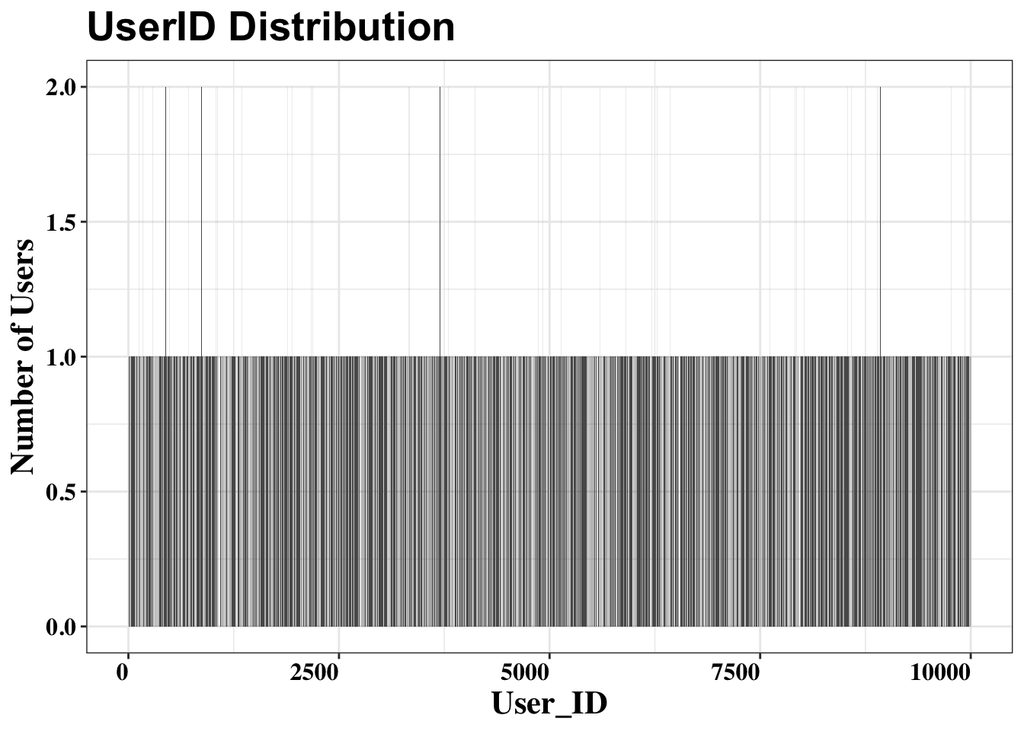

Now, there are still duplicates, but they took the same test, we decided that it makes sense to keep only the observations that bring the highest revenue.

```r
Max_Revenue_One_time_AB_Test_Results <- One_time_AB_Test_Results %>%
  group_by(USER_ID) %>%
  slice(which.max(REVENUE)) %>%
  ungroup()
```

We ended up with 4783 observations.

Then we explore with an histogram again:

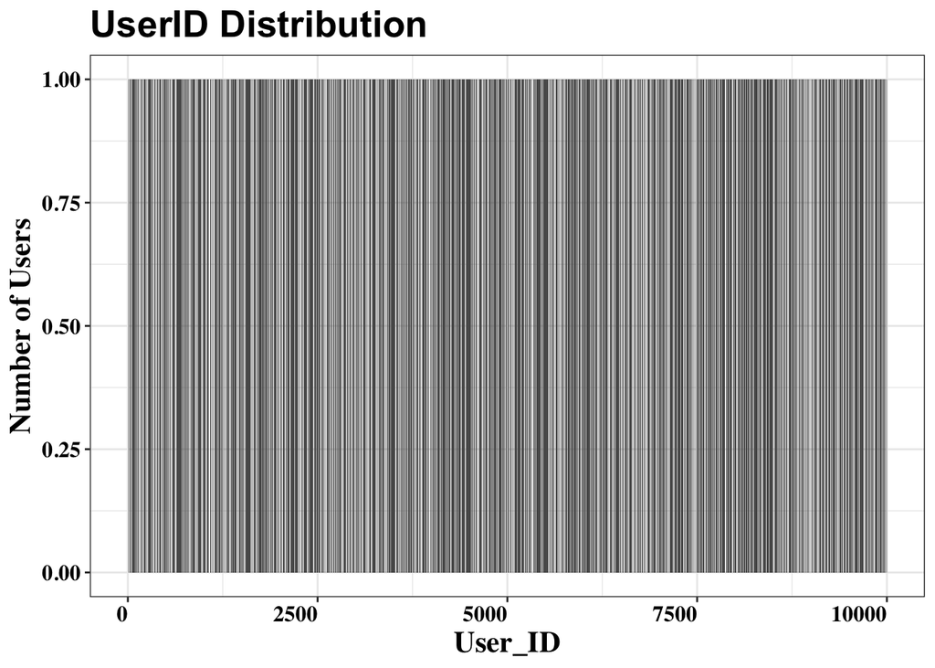

Our dataframe finally has no duplicates.

### Blanks or mispellings in CHR columns

```r
max(nchar(Max_Revenue_One_time_AB_Test_Results$VARIANT_NAME))
```

```
## [1] 7
```

```r
min(nchar(Max_Revenue_One_time_AB_Test_Results$VARIANT_NAME))
```

```
## [1] 7
```

The only 2 possibilities are “control” and “variant”, both of them have 7 characters, therefore, We can conclude that there are no blanks spaces.

### Ranges of NUM columns

```r
max(Max_Revenue_One_time_AB_Test_Results$REVENUE)
```

```
## [1] 196.01
```

```r
min(Max_Revenue_One_time_AB_Test_Results$REVENUE)
```

```
## [1] 0
```

There are not non expected values (like negative revenues).

### Filter users by VARIANT_NAME for further analysis

We decided to filter by variant name so that we could compare both groups in our analysis.

#### Control group

```r
Control_group_cleaned <- Max_Revenue_One_time_AB_Test_Results %>%
  group_by(USER_ID) %>%
  filter(VARIANT_NAME == 'control') %>%
  ungroup()
```

#### Variant group

```r
Variant_group_cleaned <- Max_Revenue_One_time_AB_Test_Results %>%
  group_by(USER_ID) %>%
  filter(VARIANT_NAME == 'variant') %>%
  ungroup()
```

## Section 3: Exploratory Data Analysis

### 1. What’s the distribution that describes the revenue among both the variant and control groups in the study?

We start with a boxplot comparing both variants.

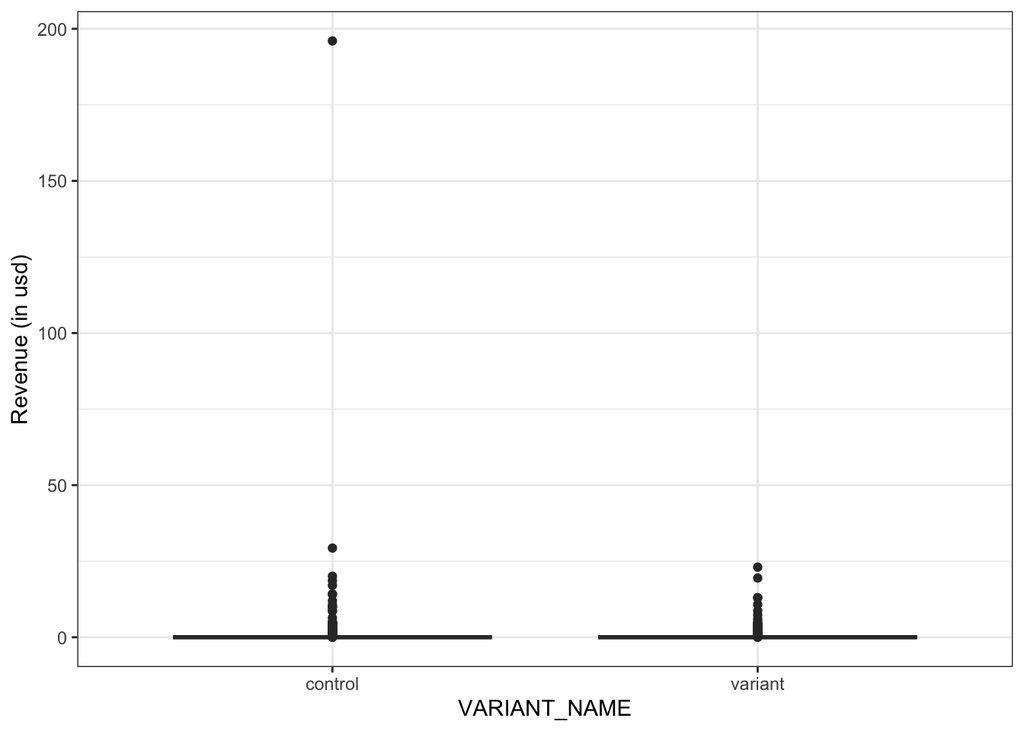

An outlier can be seen in the boxplot, we checked it with the following code:

```r
 Max_Revenue_One_time_AB_Test_Results %>%
  group_by(USER_ID) %>%
  arrange(desc(REVENUE)) %>%
head()
```

```
## # A tibble: 6 × 3
## # Groups:   USER_ID [6]
##   USER_ID VARIANT_NAME REVENUE
##     <dbl> <chr>          <dbl>
## 1    3342 control        196.
## 2    2166 control         29.3
## 3    7356 variant         23.0
## 4    1053 control         20.1
## 5    3684 variant         19.5
## 6     282 control         18.6
```

```r
Filtered_Max_Revenue_One_time_AB_Test_Results <- Max_Revenue_One_time_AB_Test_Results %>%
  filter(REVENUE != max(REVENUE))
```

Now We plot the boxplot again but without the outlier.

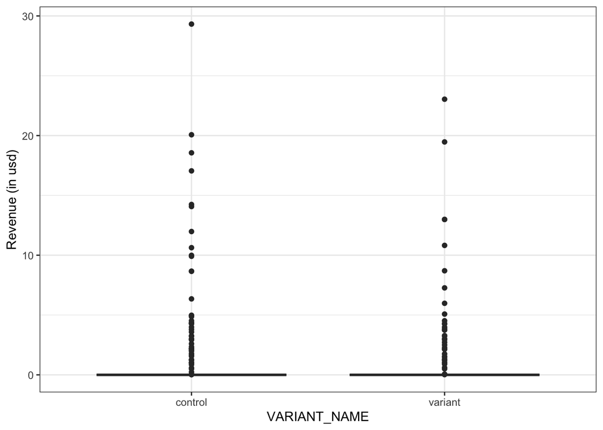

It shows clearly how the data is distributed, but We thought it would also be benefitial to explore only the observations that bring revenue (revenue >0). So we start by performing a filter.

```r
Non_Empty_Filtered_AB_Test_Results <- Filtered_Max_Revenue_One_time_AB_Test_Results %>%
  filter(REVENUE > 0)
```

```r
No_max_Control_group_cleaned <- Control_group_cleaned %>%
  filter(REVENUE != max(REVENUE))
```

```r
Non_Empty_Control_group_cleaned <- Control_group_cleaned %>%
  filter(REVENUE > 0) %>%
  filter(REVENUE != max(REVENUE))
```

```r
Non_Empty_Variant_group_cleaned <- Variant_group_cleaned %>%
  filter(REVENUE > 0)
```

Then, we plot it.

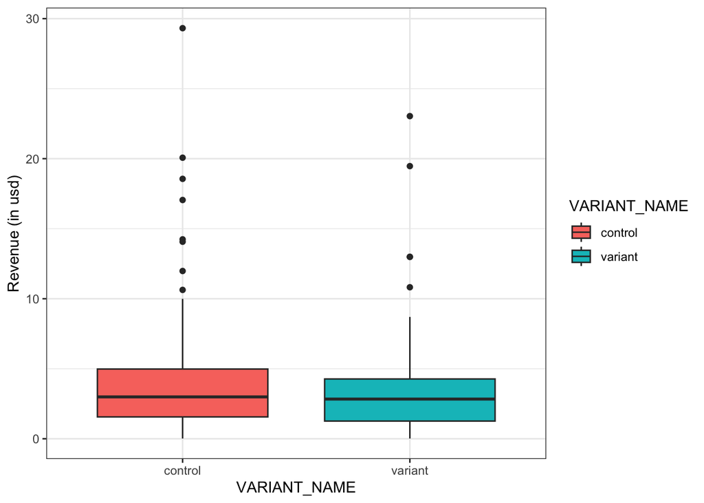

In this boxplot more information about the two groups can be observed:

1. Control group statistics (Interquartile, median, range) are higher than the ones from the variant group.
2. Control group has a higher count of values above the interquartile range.

Also, I decided to plot some histograms to explore further how the revenue is distributed.

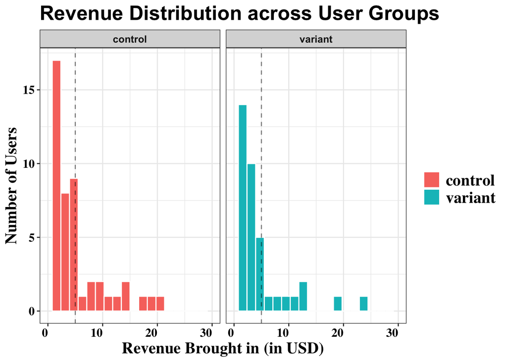

In this histogram we also learned more about how the revenue is distributed among both of the groups. An important observation is that most of the users brought less than $5.

#### Is it normally distributed?

It can be seen from the histogram that it is not normally distributed, but we decided to make a test to confirm it.

```r
#We first need to standarized the REVENUE of the control group and then store it as a vector
Standarized_Revenue_Control_group<- scale(Non_Empty_Control_group_cleaned$REVENUE)

Standarized_Revenue_Variant_group<- scale(Non_Empty_Variant_group_cleaned$REVENUE)
```

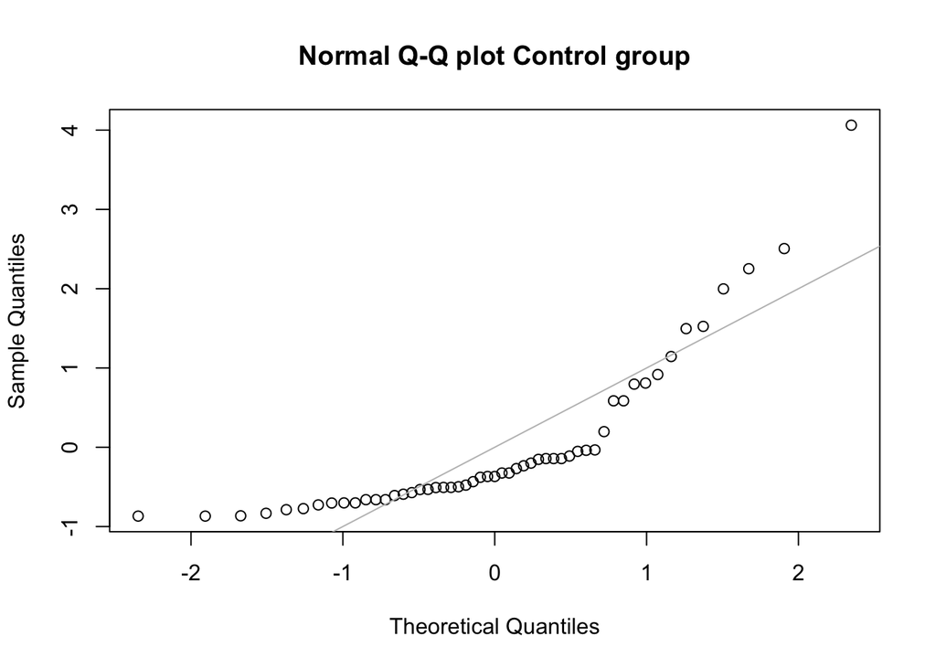

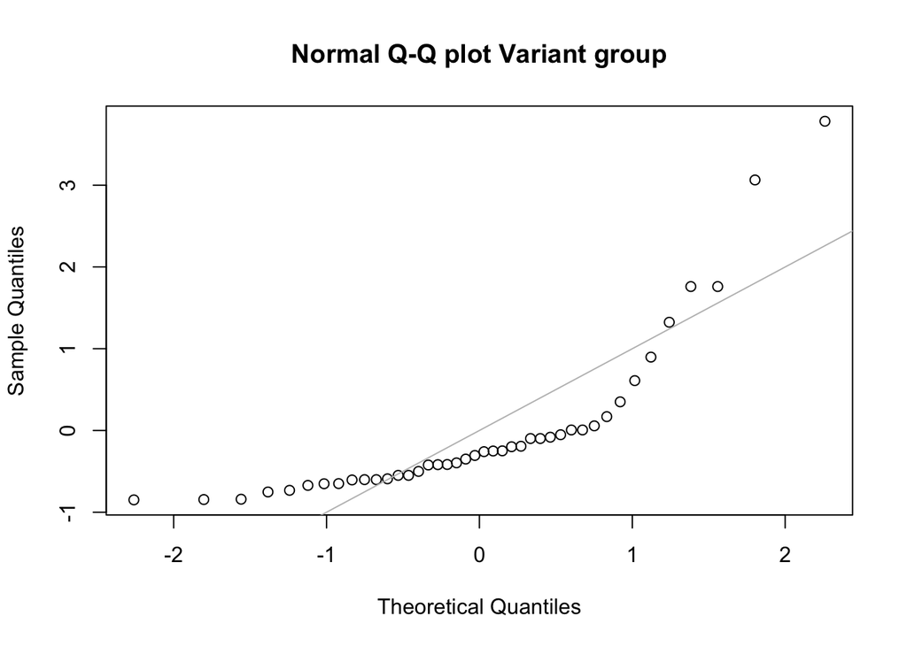

If the values were close to the line then we could conclude that it is normally distributed, but this is not the case.

### 2. What were the measures of central tendency that describe the revenue for both the variant and control groups in the study?

#### Control group

```r
control_mean <- mean(No_max_Control_group_cleaned$REVENUE)
control_mean
mean(No_max_Control_group_cleaned$REVENUE, trim=0.1)
median(No_max_Control_group_cleaned$REVENUE)
```

#### Variant group

```r
variant_mean <- mean(Variant_group_cleaned$REVENUE)
variant_mean
mean(Variant_group_cleaned$REVENUE, trim=0.1)
median(Variant_group_cleaned$REVENUE)
```

#### Control group, revenue > 0

```r
mean(Non_Empty_Control_group_cleaned$REVENUE)
mean(Non_Empty_Control_group_cleaned$REVENUE, trim=0.1)
median(Non_Empty_Control_group_cleaned$REVENUE)
```

#### Variant group, revenue > 0

```r
mean(Non_Empty_Variant_group_cleaned$REVENUE)
mean(Non_Empty_Variant_group_cleaned$REVENUE, trim=0.1)
median(Non_Empty_Variant_group_cleaned$REVENUE)
```

Summary - Measures of Central Tendency for Revenue by Group

| Group | Mean | Trimmed_Mean | Median |
| --- | --- | --- | --- |
| Control | 0.1149226 | 0.000000 | 0.000 |
| Variant | 0.0744129 | 0.000000 | 0.000 |
| Control, Revenue > 0 | 5.1801887 | 4.058140 | 2.990 |
| Variant, Revenue >0 | 4.2397619 | 3.204706 | 2.835 |

### 3.What were the measures of dispersion that describe the revenue for both the variant and control groups in the study?

#### Control group

```r
range(No_max_Control_group_cleaned$REVENUE)
sd(No_max_Control_group_cleaned$REVENUE)
IQR(No_max_Control_group_cleaned$REVENUE)
mad(No_max_Control_group_cleaned$REVENUE)
```

#### Variant group

```r
range(Variant_group_cleaned$REVENUE)
sd(Variant_group_cleaned$REVENUE)
IQR(Variant_group_cleaned$REVENUE)
mad(Variant_group_cleaned$REVENUE)
```

#### Control group, revenue > 0

```r
range(Non_Empty_Control_group_cleaned$REVENUE)
sd(Non_Empty_Control_group_cleaned$REVENUE)
IQR(Non_Empty_Control_group_cleaned$REVENUE)
mad(Non_Empty_Control_group_cleaned$REVENUE)
```

#### Variant group, revenue > 0

```r
range(Non_Empty_Variant_group_cleaned$REVENUE)
sd(Non_Empty_Variant_group_cleaned$REVENUE)
IQR(Non_Empty_Variant_group_cleaned$REVENUE)
mad(Non_Empty_Variant_group_cleaned$REVENUE)
```

Summary - Measures of Dispersion for Revenue by Group

| Group | Range | Standard_Deviation | Interquartile_range | Median_absolute_deviation |
| --- | --- | --- | --- | --- |
| Control | 0-29.32 | 1.1624946 | 0.0000 | 0.000000 |
| Variant | 0-23.04 | 0.8565554 | 0.0000 | 0.000000 |
| Control, Revenue > 0 | 0.02-29.32 | 5.9427708 | 3.4200 | 2.579724 |
| Variant, Revenue >0 | 0.02-23.04 | 4.9712738 | 3.0075 | 2.312856 |

### 4. What are some of the percentiles of revenue for both the variant and control groups in the study?

#### Control group

```r
quantile(No_max_Control_group_cleaned$REVENUE, p=c(.05, .25, .5, .75, .95, .99))
```

```
##     5%    25%    50%    75%    95%    99%
## 0.0000 0.0000 0.0000 0.0000 0.0000 3.2896
```

#### Variant group

```r
quantile(Variant_group_cleaned$REVENUE, p=c(.05, .25, .5, .75, .95, .99))
```

```
##    5%   25%   50%   75%   95%   99%
## 0.000 0.000 0.000 0.000 0.000 2.178
```

#### Control group, revenue > 0

```r
quantile(Non_Empty_Control_group_cleaned$REVENUE, p=c(.05, .25, .5, .75, .95, .99))
```

```
##     5%    25%    50%    75%    95%    99%
##  0.154  1.560  2.990  4.980 17.654 24.510
```

#### Variant group, revenue > 0

```r
quantile(Non_Empty_Variant_group_cleaned$REVENUE, p=c(.05, .25, .5, .75, .95, .99))
```

```
##      5%     25%     50%     75%     95%     99%
##  0.0820  1.2625  2.8350  4.2700 12.9900 21.5763
```

## Section 4: Statistical Analysis

### 5. What is the estimate of the standard error of revenue for both the variant and control groups in the study?

In order to estimate the standard error we decided to use the bootstrap method.

#### Standard error - Control Group

```r
library(boot)
stat_fun_control <- function(x, idx) mean(x[idx])
boot_obj_control <- boot(No_max_Control_group_cleaned$REVENUE, R=1000, statistic=stat_fun_control)
boot_obj_control
```

```
##
## ORDINARY NONPARAMETRIC BOOTSTRAP
##
##
## Call:
## boot(data = No_max_Control_group_cleaned$REVENUE, statistic = stat_fun_control,
##     R = 1000)
##
##
## Bootstrap Statistics :
##      original       bias    std. error
## t1* 0.1149226 0.0005581247  0.02263854
```

#### Standard error - Variant Group

```r
stat_fun_variant <- function(x, idx) mean(x[idx])
boot_obj_variant <- boot(Variant_group_cleaned$REVENUE, R=1000, statistic=stat_fun_variant)
boot_obj_variant
```

```
##
## ORDINARY NONPARAMETRIC BOOTSTRAP
##
##
## Call:
## boot(data = Variant_group_cleaned$REVENUE, statistic = stat_fun_variant,
##     R = 1000)
##
##
## Bootstrap Statistics :
##       original        bias    std. error
## t1* 0.07441287 -0.0002333389  0.01713641
```

### 6. What are the 95% confidence interval of revenue for both the variant and control groups in the study?

#### 95% interval - Control Group

```r
boot_ci_control <- boot.ci(boot_obj_control, conf=0.95, type='basic')
X_control <- data.frame(mean=boot_obj_control$t)
ci90_control <- boot_ci_control$basic[4:5]
ci_control <- data.frame(ci_control=ci90_control, y=c(8, 12))
ci_control
```

```
##   ci_control  y
## 1 0.06728833  8
## 2 0.15559826 12
```

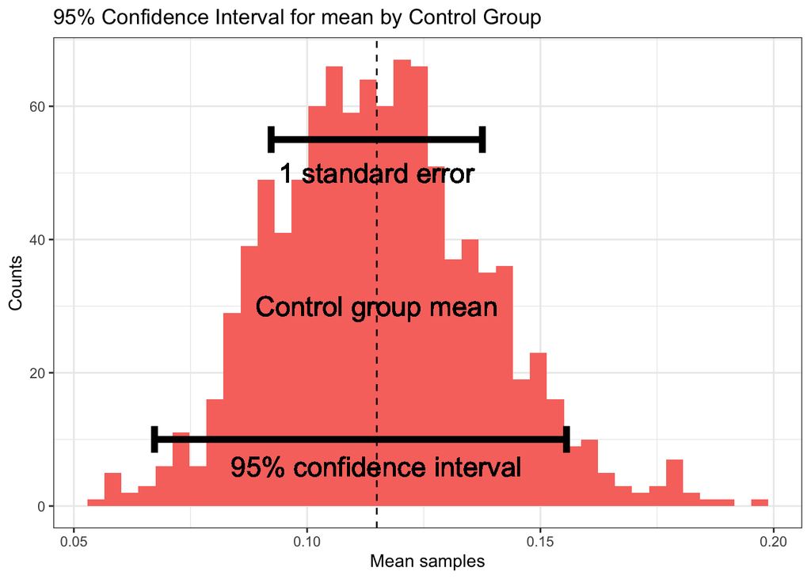

#### 95% interval - Variant Group

```r
boot_ci_variant <- boot.ci(boot_obj_variant, conf=0.95, type='basic')
X_variant <- data.frame(mean=boot_obj_variant$t)
ci90_variant <- boot_ci_variant$basic[4:5]
ci_variant <- data.frame(ci_variant=ci90_variant, y=c(8, 12))
ci_variant
```

```
##   ci_variant  y
## 1 0.03723699  8
## 2 0.10486313 12
```

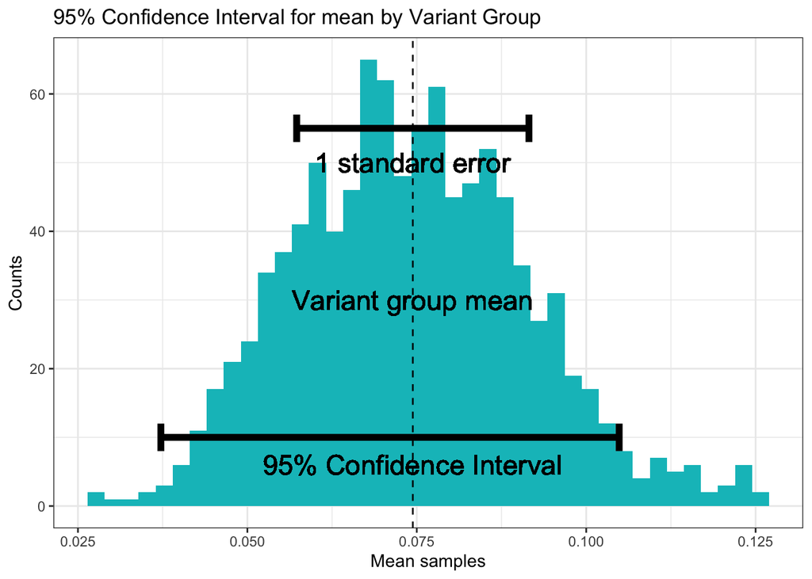

#### Comparison between the two groups sample statistic

Then we plot the density curves of both groups to see if they overlap:

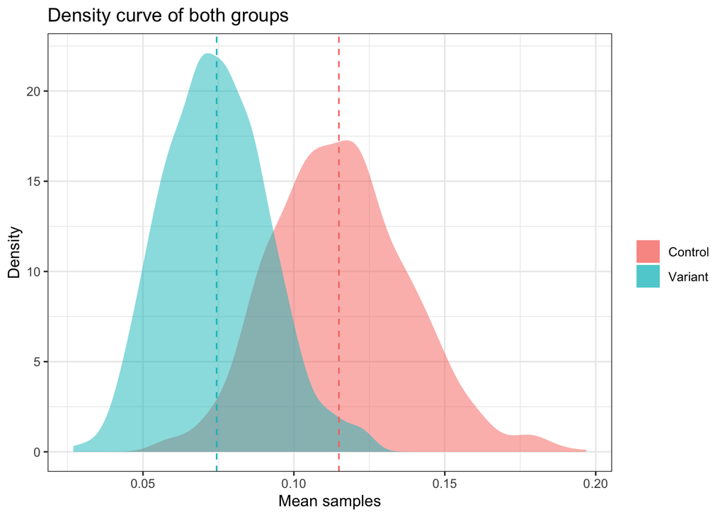

```r
ggplot() +
  stat_density(data = X_control, aes(x = mean, group = 1, fill = "Control"), alpha = 0.5) +
  stat_density(data = X_variant, aes(x = mean, group = 1, fill = "Variant"), alpha = 0.5) +
  geom_vline(data = X_control, aes(xintercept = control_mean), linetype = 2, color = "#F8766D") +
  geom_vline(data = X_variant, aes(xintercept = variant_mean), linetype = 2, color = "#00BFC4") +
  theme_bw() +
  labs(title = "Density curve of both groups", x = "Mean samples", y = "Density", fill = "") +
  scale_fill_manual(values = c("#F8766D", "#00BFC4"), labels = c("Control", "Variant"))
```

As it is noticed, their confidence intervals do overlap, therefore, no conclusions can be made about wether the control group bring more revenue.

What we can test to determine if the control group brings more revenue than the variant group is to find out if the difference between the means is statistical significant.

### 7. Is the difference between a statistic (mean or median) of both groups statistically significant?

```r
mean_diff <- control_mean-variant_mean
mean_diff
```

```
## [1] 0.04050969
```

#### Permutation test

The question is whether this difference is within the range of what random chance might produce.

One way to answer this is to apply a permutation test, combine all the revenues together and then repeatedly shuffle and divide them into groups of 2389 (recall tha n=2389 for control group) and a group of 2393 (recall tha n=2393 for variant group).

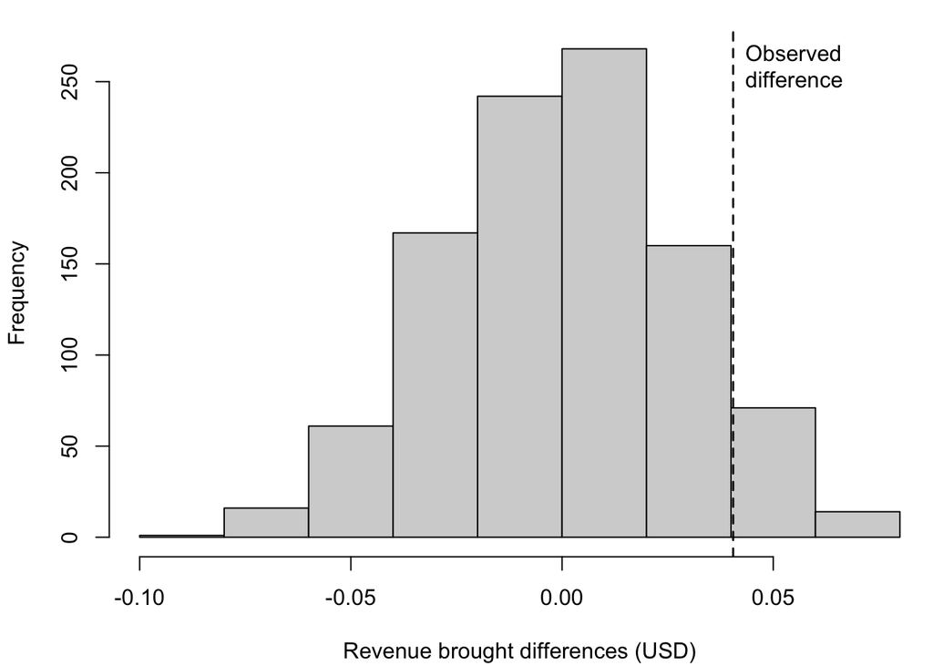

```r
set.seed(1)
perm_diffs <- rep(0, 1000)
for (i in 1:1000) {
  perm_diffs[i] = perm_fun(Filtered_Max_Revenue_One_time_AB_Test_Results$REVENUE, 2389, 2393)
}
par(mar=c(4,4,1,0)+.1)
hist(perm_diffs, xlab='Revenue brought differences (USD)', main='')
abline(v=control_mean - variant_mean, lty=2, lwd=1.5)
text('  Observed\n  difference', x=control_mean - variant_mean,  y=par()$usr[4]-20, adj=0)
```

```r
mean(perm_diffs > (control_mean - variant_mean))
```

```
## [1] 0.082
```

The histogram, shows that mean difference of random permutations often exceeds the observed difference in revenue brought (the vertical line). For our results, this happens in 8.2% of the cases.

## Section 5: Conclusion

As p-value chosen was 5%, the results suggest that the observed difference in revenue generated between the control group and variation group is well within the range of chance variation and thus is not statistically significant.